# R Notebook

Maciej Beręsewicz

Load the packages

```r
#install.packages("speedglm")
#install.packages(c("mfx", "BaylorEdPsych", "ROCR"))
library(tidyverse)
library(speedglm) ## high-performance GLM models
library(mfx) ## marginal effects for GLM models
library(BaylorEdPsych) ## pseudoR2 measures for GLM
library(ROCR) ## for prediction
```

load the data

```r
df <- readRDS("../data/data_for_lecture.rds")
df$locality <- as_factor(df$locality)
df$woj <- as_factor(df$woj)
df$gender <- as_factor(df$gender)
df
```

| respid | cluster | locality | gmina | woj | gender | age | status | status_detail |
| --- | --- | --- | --- | --- | --- | --- | --- | --- |
| 30 | 3 | miasto 20 000 - 99 999 | 202011 | Dolnośląskie | meżczyzna | 47 | 1 | 1 |
| 33 | 3 | miasto 20 000 - 99 999 | 202011 | Dolnośląskie | meżczyzna | 47 | 1 | 1 |
| 27 | 3 | miasto 20 000 - 99 999 | 202011 | Dolnośląskie | meżczyzna | 47 | 0 | 3 |
| 28 | 3 | miasto 20 000 - 99 999 | 202011 | Dolnośląskie | meżczyzna | 47 | 0 | 3 |
| 29 | 3 | miasto 20 000 - 99 999 | 202011 | Dolnośląskie | meżczyzna | 47 | 0 | 3 |
| 31 | 3 | miasto 20 000 - 99 999 | 202011 | Dolnośląskie | meżczyzna | 47 | 0 | 2 |
| 32 | 3 | miasto 20 000 - 99 999 | 202011 | Dolnośląskie | meżczyzna | 47 | 0 | 2 |
| 34 | 3 | miasto 20 000 - 99 999 | 202011 | Dolnośląskie | meżczyzna | 47 | 0 | 2 |
| 35 | 3 | miasto 20 000 - 99 999 | 202011 | Dolnośląskie | meżczyzna | 47 | 0 | 3 |
| 36 | 3 | miasto 20 000 - 99 999 | 202011 | Dolnośląskie | meżczyzna | 47 | 0 | 2 |

[output cut: 990 more lines]

```r
table(as_factor(df$status))
```

```
niezrealizowany    zrealizowany
           7246            4054
```

```r
df
```

| respid | cluster | locality | gmina | woj | gender | age | status | status_detail |
| --- | --- | --- | --- | --- | --- | --- | --- | --- |
| 30 | 3 | miasto 20 000 - 99 999 | 202011 | Dolnośląskie | meżczyzna | 47 | 1 | 1 |
| 33 | 3 | miasto 20 000 - 99 999 | 202011 | Dolnośląskie | meżczyzna | 47 | 1 | 1 |
| 27 | 3 | miasto 20 000 - 99 999 | 202011 | Dolnośląskie | meżczyzna | 47 | 0 | 3 |
| 28 | 3 | miasto 20 000 - 99 999 | 202011 | Dolnośląskie | meżczyzna | 47 | 0 | 3 |
| 29 | 3 | miasto 20 000 - 99 999 | 202011 | Dolnośląskie | meżczyzna | 47 | 0 | 3 |
| 31 | 3 | miasto 20 000 - 99 999 | 202011 | Dolnośląskie | meżczyzna | 47 | 0 | 2 |
| 32 | 3 | miasto 20 000 - 99 999 | 202011 | Dolnośląskie | meżczyzna | 47 | 0 | 2 |
| 34 | 3 | miasto 20 000 - 99 999 | 202011 | Dolnośląskie | meżczyzna | 47 | 0 | 2 |
| 35 | 3 | miasto 20 000 - 99 999 | 202011 | Dolnośląskie | meżczyzna | 47 | 0 | 3 |
| 36 | 3 | miasto 20 000 - 99 999 | 202011 | Dolnośląskie | meżczyzna | 47 | 0 | 2 |

[output cut: 990 more lines]

We build a model only with gender (glm or speedglm)

```r
summary(m1)
```

```
Call:
glm(formula = status ~ gender, family = binomial(link = "logit"),
    data = df)

Deviance Residuals:
    Min       1Q   Median       3Q      Max
-0.9609  -0.9609  -0.9148   1.4106   1.4651

Coefficients:
              Estimate Std. Error z value Pr(>|z|)
(Intercept)   -0.65479    0.03154  -20.76  < 2e-16 ***
genderkobieta  0.12165    0.04028    3.02  0.00253 **
---
Signif. codes:  0 ‘***’ 0.001 ‘**’ 0.01 ‘*’ 0.05 ‘.’ 0.1 ‘ ’ 1

(Dispersion parameter for binomial family taken to be 1)

    Null deviance: 14751  on 11299  degrees of freedom
Residual deviance: 14742  on 11298  degrees of freedom
AIC: 14746

Number of Fisher Scoring iterations: 4
```

$$P( \text{status} = 1 | \text{gender} ) = \frac{\exp(-0.65479 + 0.12165 \cdot \text{Kobieta})}{1 + \exp(-0.65479 + 0.12165 \cdot \text{Kobieta})}$$

Calculate odds ratio

```r
round(exp(coef(m1)),2)
```

```
  (Intercept) genderkobieta
         0.52          1.13
```

We calculate 95% confidence interval

```r
round(exp(confint(m1)),2)
```

```
              2.5 % 97.5 %
(Intercept)    0.49   0.55
genderkobieta  1.04   1.22
```

Let’s add age to our model

```r
m2 <- glm(formula = status ~ gender + age, data = df, family = binomial(link = "logit"))
summary(m2)
```

```
Call:
glm(formula = status ~ gender + age, family = binomial(link = "logit"),
    data = df)

Deviance Residuals:
    Min       1Q   Median       3Q      Max
-1.0280  -0.9543  -0.9125   1.3980   1.5662

Coefficients:
               Estimate Std. Error z value Pr(>|z|)
(Intercept)   -1.009360   0.084948 -11.882  < 2e-16 ***
genderkobieta  0.134056   0.040422   3.316 0.000912 ***
age            0.006496   0.001439   4.515 6.32e-06 ***
---
Signif. codes:  0 ‘***’ 0.001 ‘**’ 0.01 ‘*’ 0.05 ‘.’ 0.1 ‘ ’ 1

(Dispersion parameter for binomial family taken to be 1)

    Null deviance: 14751  on 11299  degrees of freedom
Residual deviance: 14721  on 11297  degrees of freedom
AIC: 14727

Number of Fisher Scoring iterations: 4
```

```r
round(coef(m2),2)
```

```
  (Intercept) genderkobieta           age
        -1.01          0.13          0.01
```

$$P( \text{status} = 1 | \text{gender} ) =
\frac{\exp(-1.01 + 0.13 \cdot \text{Kobieta} + 0.01 \cdot \text{age})}
{1 + \exp(-1.01 + 0.13 \cdot \text{Kobieta} + 0.01 \cdot \text{age})}$$

We calculate odds ratio to compare 20s with 50s

```r
exp(0.006496348*(50-20))
```

```
[1] 1.215178
```

```r
exp(0.006496348*(70-20))
```

```
[1] 1.383778
```

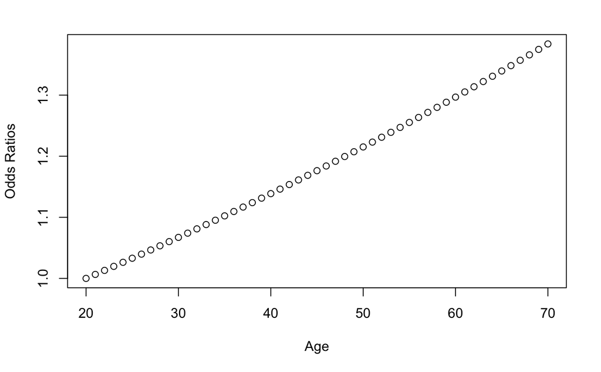

```r
summary(m3)
```

```
Generalized Linear Model of class 'speedglm':

Call:  speedglm(formula = status ~ gender + age, data = df, family = binomial(link = "logit"))

Coefficients:
 ------------------------------------------------------------------
```

|  | Estimate | Std. Error | z value | Pr(>\|z\|) |  |
| --- | --- | --- | --- | --- | --- |
| (Intercept) | -1.009360 | 0.084948 | -11.882 | 1.47e-32 | *** |
| genderkobieta | 0.134056 | 0.040422 | 3.316 | 9.12e-04 | *** |
| age | 0.006496 | 0.001439 | 4.515 | 6.32e-06 | *** |

```
-------------------------------------------------------------------
Signif. codes:  0 '***' 0.001 '**' 0.01 '*' 0.05 '.' 0.1 ' ' 1

---
null df: 11299; null deviance: 14751.07;
residuals df: 11297; residuals deviance: 14721.35;
# obs.: 11300; # non-zero weighted obs.: 11300;
AIC: 14727.35; log Likelihood: -7360.673;
RSS: 11298.8; dispersion: 1; iterations: 4;
rank: 3; max tolerance: 1.17e-13; convergence: TRUE.
```

Compare two models based on AIC, BIC – the lower the better

$$\text{AIC} = -2 \cdot LL + 2 \cdot k$$

$$\text{BIC} = -2 \cdot LL + k \cdot \log(n)$$

```r
AIC(m1, m2)
```

|  | df | AIC |
| --- | --- | --- |
| m1 | 2 | 14745.92 |
| m2 | 3 | 14727.35 |

```r
BIC(m1, m2)
```

|  | df | BIC |
| --- | --- | --- |
| m1 | 2 | 14760.58 |
| m2 | 3 | 14749.34 |

Add to the model locality – odds ratio, AIC

```r
m3 <- update(m2, . ~ . + locality)
AIC(m1, m2, m3)
```

|  | df | AIC |
| --- | --- | --- |
| m1 | 2 | 14745.92 |
| m2 | 3 | 14727.35 |
| m3 | 6 | 14448.60 |

```r
BIC(m1, m2, m3)
```

|  | df | BIC |
| --- | --- | --- |
| m1 | 2 | 14760.58 |
| m2 | 3 | 14749.34 |
| m3 | 6 | 14492.59 |

```r
summary(m3)
```

```
Call:
glm(formula = status ~ gender + age + locality, family = binomial(link = "logit"),
    data = df)

Deviance Residuals:
    Min       1Q   Median       3Q      Max
-1.1720  -0.9316  -0.8192   1.2781   1.7640

Coefficients:
                                Estimate Std. Error z value Pr(>|z|)
(Intercept)                    -0.633509   0.089013  -7.117 1.10e-12 ***
genderkobieta                   0.183999   0.041133   4.473 7.70e-06 ***
age                             0.006152   0.001461   4.212 2.53e-05 ***
localitymiasto do 19 999       -0.475442   0.057503  -8.268  < 2e-16 ***
localitymiasto 20 000 - 99 999 -0.597314   0.055034 -10.854  < 2e-16 ***
localitymiasto 100 000 +       -0.808302   0.052366 -15.436  < 2e-16 ***
---
Signif. codes:  0 ‘***’ 0.001 ‘**’ 0.01 ‘*’ 0.05 ‘.’ 0.1 ‘ ’ 1

(Dispersion parameter for binomial family taken to be 1)

    Null deviance: 14751  on 11299  degrees of freedom
Residual deviance: 14437  on 11294  degrees of freedom
AIC: 14449

Number of Fisher Scoring iterations: 4
```

```r
exp(coef(m3))
```

```
                   (Intercept)                  genderkobieta                            age
                     0.5307264                      1.2020150                      1.0061714
      localitymiasto do 19 999 localitymiasto 20 000 - 99 999       localitymiasto 100 000 +
                     0.6216105                      0.5502875                      0.4456142
```

Compare two models

```r
anova(m1, m2, m3, test = "LRT")
```

```
Analysis of Deviance Table

Model 1: status ~ gender
Model 2: status ~ gender + age
Model 3: status ~ gender + age + locality
  Resid. Df Resid. Dev Df Deviance  Pr(>Chi)
1     11298      14742
2     11297      14721  1   20.571 5.745e-06 ***
3     11294      14437  3  284.750 < 2.2e-16 ***
---
Signif. codes:  0 ‘***’ 0.001 ‘**’ 0.01 ‘*’ 0.05 ‘.’ 0.1 ‘ ’ 1
```

Calculate McFadden’s pseudo R2 – pseudoR2 (pakiet – `BaylorEdPsych`)

```r
1 - 14437/14751
```

```
[1] 0.02128669
```

Create new model

```r
m4 <- glm(formula = status ~ gender + age + locality + woj,
          data = df,
          family = binomial(link = "logit")) ## or family = "binomial"
summary(m4)
```

```
Call:
glm(formula = status ~ gender + age + locality + woj, family = binomial(link = "logit"),
    data = df)

Deviance Residuals:
    Min       1Q   Median       3Q      Max
-1.3596  -0.9596  -0.7843   1.2784   1.9257

Coefficients:
                                Estimate Std. Error z value Pr(>|z|)
(Intercept)                    -0.919456   0.119645  -7.685 1.53e-14 ***
genderkobieta                   0.096042   0.045539   2.109 0.034945 *
age                             0.005982   0.001506   3.971 7.14e-05 ***
localitymiasto do 19 999       -0.460967   0.058242  -7.915 2.48e-15 ***
localitymiasto 20 000 - 99 999 -0.604344   0.056059 -10.780  < 2e-16 ***
localitymiasto 100 000 +       -0.767982   0.053804 -14.274  < 2e-16 ***
wojKujawsko-pomorskie           0.442095   0.116310   3.801 0.000144 ***
wojLubelskie                    0.212027   0.115900   1.829 0.067340 .
wojLubuskie                     0.600071   0.145508   4.124 3.72e-05 ***
wojŁódzkie                      0.586708   0.110855   5.293 1.21e-07 ***
wojMałopolskie                  0.095324   0.104882   0.909 0.363417
wojMazowieckie                  0.143095   0.096818   1.478 0.139416
wojOpolskie                    -0.223608   0.163145  -1.371 0.170498
wojPodkarpackie                 0.634463   0.113340   5.598 2.17e-08 ***
wojPodlaskie                    0.378831   0.131421   2.883 0.003944 **
wojPomorskie                    0.470760   0.115973   4.059 4.92e-05 ***
wojŚląskie                      0.245832   0.098833   2.487 0.012870 *
wojŚwiętokrzyskie               0.865237   0.132312   6.539 6.18e-11 ***
wojWarmińsko-mazurskie          0.412201   0.130263   3.164 0.001554 **
wojWielkopolskie                0.557309   0.104268   5.345 9.04e-08 ***
wojZachodniopomorskie           0.423939   0.121826   3.480 0.000502 ***
---
Signif. codes:  0 ‘***’ 0.001 ‘**’ 0.01 ‘*’ 0.05 ‘.’ 0.1 ‘ ’ 1

(Dispersion parameter for binomial family taken to be 1)

    Null deviance: 14751  on 11299  degrees of freedom
Residual deviance: 14305  on 11279  degrees of freedom
AIC: 14347

Number of Fisher Scoring iterations: 4
```

Calculate Pseudo R2 measures using BaylorEdPsych package

```r
measures[1:4]
```

```
    McFadden Adj.McFadden    Cox.Snell   Nagelkerke
  0.03025025   0.02726742   0.03871928   0.05311746
```

How good is the model on predicting our Y variable

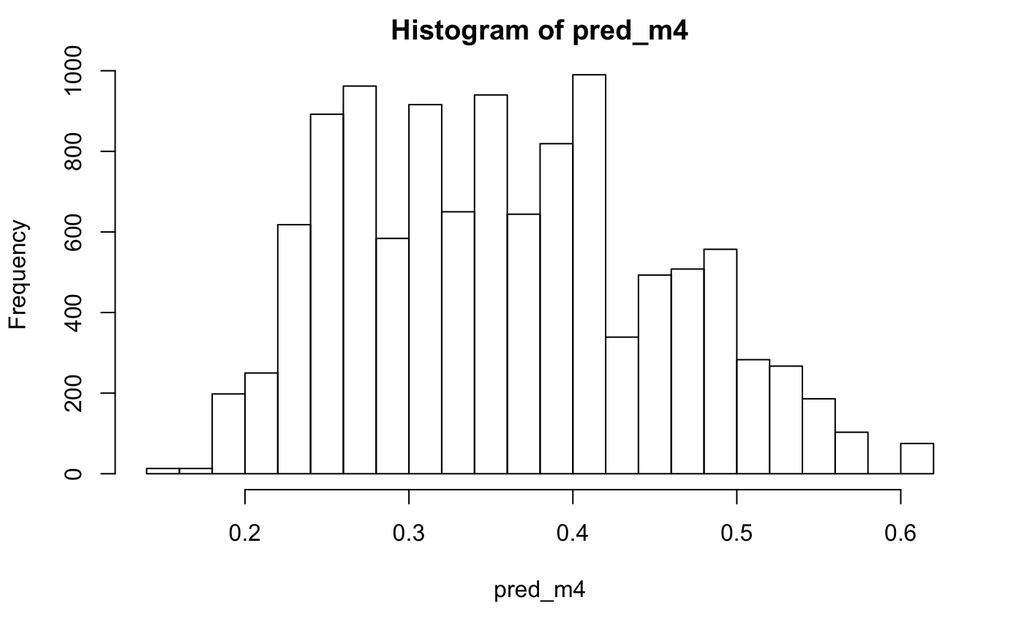

In order to predict the class (Y = 1 or Y = 0) we need to apply some threshold, by default we can use 0.5.

Confusion Matrix – in rows we have observed values of Y and in columns we have predictions

```r
conftab1
```

```
        FALSE TRUE
  FALSE  6817  429
  TRUE   3569  485
```

- TP = 485, TN = 6817, FP = 429, FN = 3569
- Accuracy: (TP+TN)/Total

```r
(485+6817) / sum(conftab1)*100
```

```
[1] 64.61947
```

- Misclassification Rate: (FP+FN)/Total

```r
(429+3569)/sum(conftab1)*100
```

```
[1] 35.38053
```

- True Positive Rate - TP/ actual yes

```r
485/(485+3569)
```

```
[1] 0.1196349
```

- False Positive Rate - FP/actual no

```r
429/(429+6817)
```

```
[1] 0.05920508
```

- Specificity – TN/actual no

```r
6817/(6817+429)
```

```
[1] 0.9407949
```

- Precision – TP/predicted yes

```r
485/(485 + 429)
```

```
[1] 0.5306346
```

1. problem is our sample – it is not balanced (not 50/50)
2. if our sample is unbalanced then using threshold 0.5 is meaningless – we should use value that is closer to share of Ys==1 in our data.
3. there is a room for optimization – select threshold to maximize selected measures

```r
conftab1 <- table(df$status == 1, pred_m4 >= 0.50)
conftab2 <- table(df$status == 1, pred_m4 >= 0.35)
prop.table(conftab1, margin = 1)
```

```
             FALSE       TRUE
  FALSE 0.94079492 0.05920508
  TRUE  0.88036507 0.11963493
```

```r
prop.table(conftab2, margin = 1)
```

```
            FALSE      TRUE
  FALSE 0.5598951 0.4401049
  TRUE  0.4020720 0.5979280
```

Now proceed to ROCR package

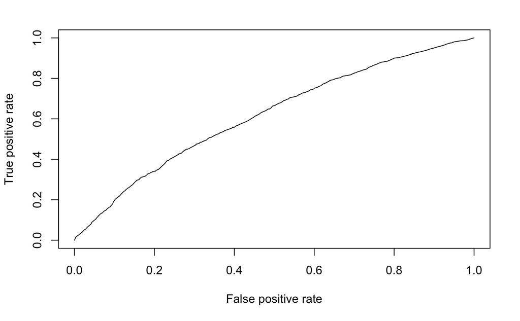

## Calculate marginal effects

```r
mf_model1
```

```
Call:
mfx::logitmfx(formula = status ~ age + gender + locality, data = df)

Marginal Effects:
                                     dF/dx   Std. Err.        z     P>|z|
age                             0.00140843  0.00033428   4.2133 2.517e-05 ***
genderkobieta                   0.04186198  0.00929142   4.5054 6.623e-06 ***
localitymiasto do 19 999       -0.10308193  0.01169249  -8.8161 < 2.2e-16 ***
localitymiasto 20 000 - 99 999 -0.12829487  0.01093894 -11.7283 < 2.2e-16 ***
localitymiasto 100 000 +       -0.17171242  0.01010226 -16.9974 < 2.2e-16 ***
---
Signif. codes:  0 ‘***’ 0.001 ‘**’ 0.01 ‘*’ 0.05 ‘.’ 0.1 ‘ ’ 1

dF/dx is for discrete change for the following variables:

[1] "genderkobieta"                  "localitymiasto do 19 999"       "localitymiasto 20 000 - 99 999"
[4] "localitymiasto 100 000 +"
```

```r
mf_model2 <- mfx::logitor(formula = status ~ age + gender + locality, data = df)
mf_model2
```

```
Call:
mfx::logitor(formula = status ~ age + gender + locality, data = df)

Odds Ratio:
                               OddsRatio Std. Err.        z     P>|z|
age                            1.0061714 0.0014698   4.2117 2.534e-05 ***
genderkobieta                  1.2020150 0.0494426   4.4733 7.703e-06 ***
localitymiasto do 19 999       0.6216105 0.0357447  -8.2681 < 2.2e-16 ***
localitymiasto 20 000 - 99 999 0.5502875 0.0302845 -10.8535 < 2.2e-16 ***
localitymiasto 100 000 +       0.4456142 0.0233348 -15.4357 < 2.2e-16 ***
---
Signif. codes:  0 ‘***’ 0.001 ‘**’ 0.01 ‘*’ 0.05 ‘.’ 0.1 ‘ ’ 1
```

```r
exp(coef(ods_model2))
```

```
                   (Intercept)                            age                  genderkobieta
                     0.5307264                      1.0061714                      1.2020150
      localitymiasto do 19 999 localitymiasto 20 000 - 99 999       localitymiasto 100 000 +
                     0.6216105                      0.5502875                      0.4456142
```

– LASSO – glmnet – when Xs are correlated, when # variables > # cases, for prediction – logistf – perfect separation in logistic regression – rms package – regression modelling strategies